# Installing spark in windows

https://bigdata-madesimple.com/guide-to-install-spark-and-use-pyspark-from-jupyter-in-windows/#:~:text=Using%20Spark%20from%20Jupyter,run%20spark%20from%20Jupyter%20notebook.

```python
import findspark

findspark.init()
```

### master() – If you are running it on the cluster you need to use your master name as an argument to master(). usually, it would be either yarn (Yet Another Resource Negotiator) or mesos depends on your cluster setup.In realtime application, you will pass master from spark-submit instead of hardcoding on Spark application.

### Use local[x] when running in Standalone mode. x should be an integer value and should be greater than 0; this represents how many partitions it should create when using RDD, DataFrame, and Dataset. Ideally, x value should be the number of CPU cores you have.

### appName() – Used to set your application name.

### getOrCreate() – This returns a SparkSession object if already exists, creates new one if not exists.

### Note: Creating SparkSession object, it internally creates one SparkContext per JVM.

```python
from pyspark.sql import SparkSession

#multiple sessions can be created

spark = SparkSession.builder.master("local[4]").appName("practice").getOrCreate()


#df = spark.sql("select 'spark' as hello ")

#df.show()
spark
```

**SparkSession - in-memory**

**SparkContext**

[Spark UI](http://Futurense:4040)

**Version**

`v3.2.0`

**Master**

`local[4]`

**AppName**

`practice`

# RDD Benefits

## In-Memory Processing

### PySpark loads the data from disk and process in memory and keeps the data in memory, this is the main difference between PySpark and Mapreduce (I/O intensive). In between the transformations, we can also cache/persists the RDD in memory to reuse the previous computations.

## Immutability

### PySpark RDD’s are immutable in nature meaning, once RDDs are created you cannot modify. When we apply transformations on RDD, PySpark creates a new RDD and maintains the RDD Lineage.

## Fault Tolerance

### PySpark operates on fault-tolerant data stores on HDFS, S3 e.t.c hence any RDD operation fails, it automatically reloads the data from other partitions. Also, When PySpark applications running on a cluster, PySpark task failures are automatically recovered for a certain number of times (as per the configuration) and finish the application seamlessly.

## Lazy Evolution

### PySpark does not evaluate the RDD transformations as they appear/encountered by Driver instead it keeps the all transformations as it encounters(DAG) and evaluates the all transformation when it sees the first RDD action.

## Partitioning

### When you create RDD from a data, It by default partitions the elements in a RDD. By default it partitions to the number of cores available.

# RDD Creation

## using parallelize()

### SparkContext has several functions to use with RDDs. For example, it’s parallelize() method is used to create an RDD from a list.

```python
print(spark)
rdd=spark.sparkContext.parallelize([1,2,3,4,5,6])

print("RDD Count:",rdd.count())

rdd1=spark.sparkContext.parallelize([10,20,30,40,40])

print("RDD1 Count:",rdd1.count())


#Create RDD from parallelize
dataList = [("Java", 20000), ("Python", 100000), ("Scala", 3000)]
rdd2=spark.sparkContext.parallelize(dataList)

for i in rdd2.collect():
    print(i)

print("Number of partitions : ",rdd2.getNumPartitions())
```

```
<pyspark.sql.session.SparkSession object at 0x000001EF68C33C88>
RDD Count: 6
RDD1 Count: 5
('Java', 20000)
('Python', 100000)
('Scala', 3000)
Number of partitions :  4
```

## using textFile()

### RDD can also be created from a text file using textFile() function of the SparkContext.

```python
rdd3=spark.sparkContext.textFile("C:\\Users\\Dell\\Documents\\Interview prep\\demo.txt")
rdd3.collect()
#Once you have an RDD, you can perform transformation and action operations. Any operation you perform on RDD runs in parallel.
```

```
['PySpark is an interface for Apache Spark in Python. It not only allows you to write Spark applications using Python APIs, but also provides the PySpark shell for interactively analyzing your data in a distributed environment. PySpark supports most of Spark’s features such as Spark SQL, DataFrame, …
```

## using wholeTextFiles()

### This function returns a PairRDD with the key being the file path and value being file content.

```python
rdd3=spark.sparkContext.wholeTextFiles("C:\\Users\\Dell\\Documents\\Interview prep\\demo.txt")
rdd3.collect()
#rdd3.getNumPartitions()
```

```
[('file:/C:/Users/Dell/Documents/Interview prep/demo.txt',
  'PySpark is an interface for Apache Spark in Python. It not only allows you to write Spark applications using Python APIs, but also provides the PySpark shell for interactively analyzing your data in a distributed environment. PySpark supports most of Spark’s features such as Spark SQL, DataFrame,…
```

## Create empty RDD using sparkContext.emptyRDD

```python
# Creates empty RDD with no partition
erdd=spark.sparkContext.emptyRDD
```

## Creating empty RDD with partition

### Some times we may need to write an empty RDD to files by partition, In this case, you should create an empty RDD with partition.

```python
#Creates empty RDD with partition
errdp=spark.sparkContext.parallelize([],10)
```

## get number of partitions using getNumPartitions()

### When we use parallelize() or textFile() or wholeTextFiles() methods of SparkContxt to initiate RDD, it automatically splits the data into partitions based on resource availability. when you run it on a laptop it would create partitions as the same number of cores available on your system.

```python
errdp.getNumPartitions()
```

```
10
```

## Set parallelize manually

### We can also set a number of partitions manually, all, we need is, to pass a number of partitions as the second parameter to these functions

```python
mrdd=spark.sparkContext.parallelize([1,2,3,4,56,7,8,9,12,3], 10)
mrdd.getNumPartitions()
```

```
10
```

## Repartition and Coalesce

### Some times we may need to repartition the RDD, PySpark provides two ways to repartition; first using repartition() method which shuffles data from all nodes also called full shuffle and second coalesce() method which shuffle data from minimum nodes, for examples if you have data in 4 partitions and doing coalesce(2) moves data from just 2 nodes.

### Both of the functions take the number of partitions to repartition rdd as shown below. Note that repartition() method is a very expensive operation as it shuffles data from all nodes in a cluster.

```python
mrdd1=mrdd.repartition(5)
print("Original RDD mrdd Partition:",mrdd.getNumPartitions(),"Returned RDD mrdd1 partition:",mrdd1.getNumPartitions())

#using repartition we can either increase or decrease the partitions
rrdd=mrdd.repartition(15)
print("Original RDD mrdd Partition:",mrdd.getNumPartitions(),"Returned RDD rrdd partition:",rrdd.getNumPartitions())

#using coalesce we can only reduce the no.of partitions but we can't increase it
mrdd2=mrdd1.coalesce(10)
print("Original RDD mrdd1 Partition:",mrdd1.getNumPartitions(),"Returned RDD mrdd2 partition:",mrdd2.getNumPartitions())

crdd=mrdd1.coalesce(3)
print("Original RDD mrdd1 Partition:",mrdd1.getNumPartitions(),"Returned RDD crdd partition:",crdd.getNumPartitions())
```

```
Original RDD mrdd Partition: 10 Returned RDD mrdd1 partition: 5
Original RDD mrdd Partition: 10 Returned RDD rrdd partition: 15
Original RDD mrdd1 Partition: 5 Returned RDD mrdd2 partition: 5
Original RDD mrdd1 Partition: 5 Returned RDD crdd partition: 3
```

# RDD Operations

## RDD transformations

### – Transformations are lazy operations, instead of updating an RDD, these operations return another RDD.

## RDD actions

### – operations that trigger computation and return RDD values.

# RDD Transformations

### Transformations on PySpark RDD returns another RDD and transformations are lazy meaning they don’t execute until you call an action on RDD. Some transformations on RDD’s are flatMap(), map(), reduceByKey(), filter(), sortByKey() and return new RDD instead of updating the current.

## RDD Transformation Types

### There are two types of transformations.

## Narrow Transformation

### Narrow transformations are the result of map() and filter() functions and these compute data that live on a single partition meaning there will not be any data movement between partitions to execute narrow transformations.

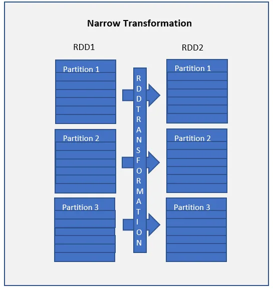

### Functions such as map(), mapPartition(), flatMap(), filter(), union() are some examples of narrow transformation

## Wider Transformation

### Wider transformations are the result of groupByKey() and reduceByKey() functions and these compute data that live on many partitions meaning there will be data movements between partitions to execute wider transformations. Since these shuffles the data, they also called shuffle transformations.

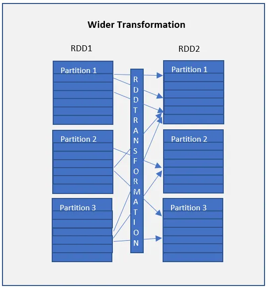

### Functions such as groupByKey(), aggregateByKey(), aggregate(), join(), repartition() are some examples of a wider transformations.

### Note: When compared to Narrow transformations, wider transformations are expensive operations due to shuffling.

# PySpark RDD Transformation functions

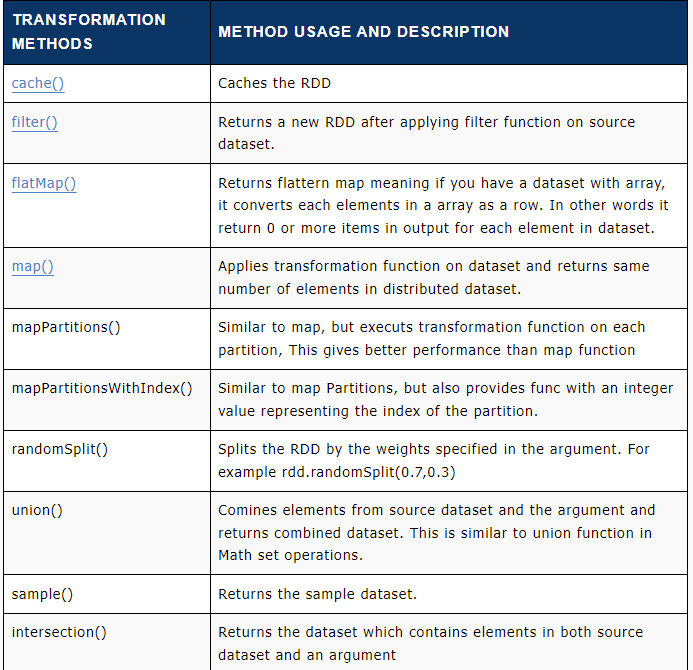

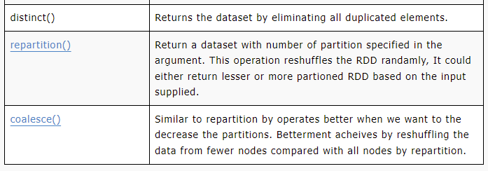

```python
test_rdd=spark.sparkContext.textFile("C:\\Users\\Dell\\Documents\\Interview prep\\test.txt",4)
test_rdd.getNumPartitions()
```

```
4
```

## RDD.sample(withReplacement, fraction, seed=None)[source]

### Return a sampled subset of this RDD.

### Parameters

### withReplacementbool

### - can elements be sampled multiple times (replaced when sampled out)

### fractionfloat

### - expected size of the sample as a fraction of this RDD’s size without replacement: probability that each element is chosen; fraction must be [0, 1] with replacement: expected number of times each element is chosen; fraction must be >= 0

### seedint, optional

### - seed for the random number generator

### Notes: This is not guaranteed to provide exactly the fraction specified of the total count of the given DataFrame.

```python
print(test_rdd.sample(False,0.1).collect())
#sample without seed will result in different result at every run
print(test_rdd.sample(False,0.1).collect())
print(test_rdd.sample(False,0.1,123).collect())
#sample with seed will result in same set of result at every run
print(test_rdd.sample(False,0.1,123).collect())
```

```
['by Lewis Carroll', 'at no cost and with', 'at no cost and with', 'Project Gutenberg’s', 'Alice’s Adventures in Wonderland', 'This eBook is for the use', 'Alice’s Adventures in Wonderland', 'Project Gutenberg’s', 'Alice’s Adventures in Wonderland', 'at no cost and with', 'Project Gutenberg’s', 'by …
['of anyone anywhere', 'at no cost and with', 'by Lewis Carroll', 'This eBook is for the use', 'at no cost and with', 'by Lewis Carroll', 'This eBook is for the use', 'at no cost and with', 'Project Gutenberg’s', 'by Lewis Carroll', 'of anyone anywhere']
['at no cost and with', 'by Lewis Carroll', 'of anyone anywhere', 'at no cost and with', 'by Lewis Carroll', 'of anyone anywhere', 'This eBook is for the use', 'Project Gutenberg’s', 'Alice’s Adventures in Wonderland', 'This eBook is for the use', 'of anyone anywhere', 'of anyone anywhere', 'by Lewi…
['at no cost and with', 'by Lewis Carroll', 'of anyone anywhere', 'at no cost and with', 'by Lewis Carroll', 'of anyone anywhere', 'This eBook is for the use', 'Project Gutenberg’s', 'Alice’s Adventures in Wonderland', 'This eBook is for the use', 'of anyone anywhere', 'of anyone anywhere', 'by Lewi…
```

## flatMap

### – flatMap() transformation flattens the RDD after applying the function and returns a new RDD. On the below example, first, it splits each record by space in an RDD and finally flattens it. Resulting RDD consists of a single word on each record.

```python
test_rdd1=test_rdd.flatMap(lambda x:x.split(" "))
test_rdd1.collect()
```

```
['Project',
 'Gutenberg’s',
 'Alice’s',
 'Adventures',
 'in',
 'Wonderland',
 'by',
 'Lewis',
 'Carroll',
 'This',
 'eBook',
 'is',
 'for',
 'the',
 'use',
 'of',
 'anyone',
 'anywhere',
 'at',
 'no',
 'cost',
 'and',
 'with',
 'Alice’s',
 'Adventures',
 'in',
 'Wonderland',
 'by',
 'Lewis',
 'Carroll',
 'This',
 'eBook',
 'is',
 'for',
 'the',
 'use',
 'of',
 'anyone',
 'anywhere',
 'at',
```

[output cut: 467 more lines]

```
 'with',
 'This',
 'eBook',
 'is',
 'for',
 'the',
 'use',
 'of',
 'anyone',
 'anywhere',
 'at',
 'no',
 'cost',
 'and',
 'with']
```

## map

### – map() transformation is used to apply any complex operations like adding a column, updating a column e.t.c, the output of map transformations would always have the same number of records as input.

### In our word count example, we are adding a new column with value 1 for each word, the result of the RDD is PairRDDFunctions which contains key-value pairs, word of type String as Key and 1 of type Int as value.

```python
test_rdd2=test_rdd1.map(lambda x:(x,1))
test_rdd2.collect()
```

```
[('Project', 1),
 ('Gutenberg’s', 1),
 ('Alice’s', 1),
 ('Adventures', 1),
 ('in', 1),
 ('Wonderland', 1),
 ('by', 1),
 ('Lewis', 1),
 ('Carroll', 1),
 ('This', 1),
 ('eBook', 1),
 ('is', 1),
 ('for', 1),
 ('the', 1),
 ('use', 1),
 ('of', 1),
 ('anyone', 1),
 ('anywhere', 1),
 ('at', 1),
 ('no', 1),
 ('cost', 1),
 ('and', 1),
 ('with', 1),
 ('Alice’s', 1),
 ('Adventures', 1),
 ('in', 1),
 ('Wonderland', 1),
 ('by', 1),
 ('Lewis', 1),
 ('Carroll', 1),
 ('This', 1),
 ('eBook', 1),
 ('is', 1),
 ('for', 1),
 ('the', 1),
 ('use', 1),
 ('of', 1),
 ('anyone', 1),
 ('anywhere', 1),
 ('at', 1),
```

[output cut: 467 more lines]

```
 ('with', 1),
 ('This', 1),
 ('eBook', 1),
 ('is', 1),
 ('for', 1),
 ('the', 1),
 ('use', 1),
 ('of', 1),
 ('anyone', 1),
 ('anywhere', 1),
 ('at', 1),
 ('no', 1),
 ('cost', 1),
 ('and', 1),
 ('with', 1)]
```

## reduceByKey

### – reduceByKey() merges the values for each key with the function specified. In our example, it reduces the word string by applying the sum function on value. The result of our RDD contains unique words and their count.

```python
test_rdd3=test_rdd2.reduceByKey(lambda x,y:x+y)
test_rdd3.collect()
```

```
[('Gutenberg’s', 9),
 ('Alice’s', 18),
 ('in', 18),
 ('of', 27),
 ('no', 27),
 ('Adventures', 18),
 ('Wonderland', 18),
 ('by', 18),
 ('eBook', 27),
 ('the', 27),
 ('cost', 27),
 ('and', 27),
 ('Project', 9),
 ('Lewis', 18),
 ('Carroll', 18),
 ('is', 27),
 ('use', 27),
 ('anyone', 27),
 ('anywhere', 27),
 ('at', 27),
 ('This', 27),
 ('for', 27),
 ('with', 27)]
```

## sortByKey

### – sortByKey() transformation is used to sort RDD elements on key. In our example, first, we convert RDD[(String,Int]) to RDD[(Int, String]) using map transformation and apply sortByKey which ideally does sort on an integer value. And finally, foreach with println statements returns all words in RDD and their count as key-value pair

### RDD.sortByKey(ascending=True, numPartitions=None, keyfunc=<function RDD.>)

```python
test_rdd4=test_rdd3.map(lambda x:(x[1],x[0])).sortByKey(False)
test_rdd4.collect()# collect is an action
```

```
[(27, 'of'),
 (27, 'no'),
 (27, 'eBook'),
 (27, 'the'),
 (27, 'cost'),
 (27, 'and'),
 (27, 'is'),
 (27, 'use'),
 (27, 'anyone'),
 (27, 'anywhere'),
 (27, 'at'),
 (27, 'This'),
 (27, 'for'),
 (27, 'with'),
 (18, 'Alice’s'),
 (18, 'in'),
 (18, 'Adventures'),
 (18, 'Wonderland'),
 (18, 'by'),
 (18, 'Lewis'),
 (18, 'Carroll'),
 (9, 'Gutenberg’s'),
 (9, 'Project')]
```

## we can also sort using sortBy or takeOrdered

## sortBy

### -sortBy() is used to sort the data by value efficiently in pyspark. It is a method available in rdd.

### Syntax: rdd.sortBy(lambda expression,ascending=True, numPartitions=None)

### It uses a lambda expression to sort the data based on columns.

### lambda expression: lambda x: x[column_index]

```python
print(test_rdd3.sortBy(lambda x:x[1],False).collect())
#it returns pipelined RDD
print(type(test_rdd3.sortBy(lambda x:x[1])))
```

```
[('of', 27), ('no', 27), ('eBook', 27), ('the', 27), ('cost', 27), ('and', 27), ('is', 27), ('use', 27), ('anyone', 27), ('anywhere', 27), ('at', 27), ('This', 27), ('for', 27), ('with', 27), ('Alice’s', 18), ('in', 18), ('Adventures', 18), ('Wonderland', 18), ('by', 18), ('Lewis', 18), ('Carroll', …
<class 'pyspark.rdd.PipelinedRDD'>
```

## takeOrdered

### It is the method available in RDD, this is used to sort values based on values in a particular column.

### Syntax: rdd.takeOrdered(n,lambda expression)

### where, n is the total rows to be displayed after sorting

```python
print(test_rdd3.takeOrdered(10,lambda x:x[1]))
#it returns list
print(type(test_rdd3.takeOrdered(10,lambda x:x[1])))
```

```
[('Gutenberg’s', 9), ('Project', 9), ('Alice’s', 18), ('in', 18), ('Adventures', 18), ('Wonderland', 18), ('by', 18), ('Lewis', 18), ('Carroll', 18), ('of', 27)]
<class 'list'>
```

## filter

### – filter() transformation is used to filter the records in an RDD. In our example we are filtering all words starts with “a”.

```python
test_rdd5=test_rdd4.filter(lambda x: "a" in x[1][0])
test_rdd5.collect()
```

```
[(27, 'and'), (27, 'anyone'), (27, 'anywhere'), (27, 'at')]
```

## Join

### -RDD.join(other, numPartitions=None)

Return an RDD containing all pairs of elements with matching keys in self and other.

Each pair of elements will be returned as a (k, (v1, v2)) tuple, where (k, v1) is in self and (k, v2) is in other.

Performs a hash join across the cluster.

```python
temp=test_rdd3.filter(lambda x:"a" in x[0][0])
t=test_rdd3.join(temp)
t.collect()
```

```
[('and', (27, 27)),
 ('anyone', (27, 27)),
 ('anywhere', (27, 27)),
 ('at', (27, 27))]
```

# RDD Actions

### RDD Action operations return the values from an RDD to a driver program. In other words, any RDD function that returns non-RDD is considered as an action.

## count()

### – Returns the number of records in an RDD

```python
test_rdd3.count()
```

```
23
```

## CountByKey()

### Count the number of elements for each key, and return the result to the master as a dictionary.

```python
count=test_rdd2.countByKey()
print(count)
print(type(count))
```

```
defaultdict(<class 'int'>, {'Project': 9, 'Gutenberg’s': 9, 'Alice’s': 18, 'Adventures': 18, 'in': 18, 'Wonderland': 18, 'by': 18, 'Lewis': 18, 'Carroll': 18, 'This': 27, 'eBook': 27, 'is': 27, 'for': 27, 'the': 27, 'use': 27, 'of': 27, 'anyone': 27, 'anywhere': 27, 'at': 27, 'no': 27, 'cost': 27, '…
<class 'collections.defaultdict'>
```

## first()

### – Returns the first record.

```python
test_rdd3.first()
```

```
('Gutenberg’s', 9)
```

## max()

### – Returns max record.

```python
test_rdd3.max()
```

```
('with', 27)
```

## reduce()

### – Reduces the records to single, we can use this to count or sum.

```python
totalWordCount = test_rdd4.reduce(lambda a,b: (a[0]+b[0],a[1]))
totalWordCount[0]
```

```
522
```

## take()

### – Returns the record specified as an argument.

```python
data3 = test_rdd3.take(3)
for f in data3:
    print("data3 Key:"+ f[0] +", Value:"+str(f[1]))
```

```
data3 Key:Gutenberg’s, Value:9
data3 Key:Alice’s, Value:18
data3 Key:in, Value:18
```

## collect()

### – Returns all data from RDD as an array. Be careful when you use this action when you are working with huge RDD with millions and billions of data as you may run out of memory on the driver.

```python
# Action - collect
data = test_rdd3.collect()
for f in data:
    print("Key:"+ f[0] +", Value:"+str(f[1]))
```

```
Key:Gutenberg’s, Value:9
Key:Alice’s, Value:18
Key:in, Value:18
Key:of, Value:27
Key:no, Value:27
Key:Adventures, Value:18
Key:Wonderland, Value:18
Key:by, Value:18
Key:eBook, Value:27
Key:the, Value:27
Key:cost, Value:27
Key:and, Value:27
Key:Project, Value:9
Key:Lewis, Value:18
Key:Carroll, Value:18
Key:is, Value:27
Key:use, Value:27
Key:anyone, Value:27
Key:anywhere, Value:27
Key:at, Value:27
Key:This, Value:27
Key:for, Value:27
Key:with, Value:27
```

## saveAsTextFile()

### – Using saveAsTestFile action, we can write the RDD to a text file.

```python
try:
    test_rdd3.saveAsTextFile("C:\\Users\\Dell\\Documents\\Interview prep\\wordCountOutput")
except:
    pass
```

# Types of RDD

## PairRDDFunctions or PairRDD – Pair RDD is a key-value pair This is mostly used RDD type,

## ShuffledRDD –

## DoubleRDD –

## SequenceFileRDD –

## HadoopRDD –

## ParallelCollectionRDD –

```python
#to print the RDD lineage information
print(test_rdd3.toDebugString())
```

```
b'(4) PythonRDD[34] at collect at <ipython-input-50-82b1294aee4e>:2 []\n |  MapPartitionsRDD[33] at mapPartitions at PythonRDD.scala:145 []\n |  ShuffledRDD[32] at partitionBy at NativeMethodAccessorImpl.java:0 []\n +-(4) PairwiseRDD[31] at reduceByKey at <ipython-input-50-82b1294aee4e>:1 []\n    | …
```

## Shuffle Operations

### For example, when we perform reduceByKey() operation, PySpark does the following

### - PySpark first runs map tasks on all partitions which groups all values for a single key.

### - The results of the map tasks are kept in memory.

### - When results do not fit in memory, PySpark stores the data into a disk.

### - PySpark shuffles the mapped data across partitions, some times it also stores the shuffled data into a disk for reuse when it needs to recalculate.

### - Run the garbage collection

### - Finally runs reduce tasks on each partition based on key.

### PySpark RDD triggers shuffle and repartition for several operations like repartition() and coalesce(), groupByKey(), reduceByKey(), cogroup() and join() but not countByKey() .

## Shuffle partition size & Performance

### Based on your dataset size, a number of cores and memory PySpark shuffling can benefit or harm your jobs. When you dealing with less amount of data, you should typically reduce the shuffle partitions otherwise you will end up with many partitioned files with less number of records in each partition. which results in running many tasks with lesser data to process.

### On other hand, when you have too much of data and having less number of partitions results in fewer longer running tasks and some times you may also get out of memory error.

### Getting the right size of the shuffle partition is always tricky and takes many runs with different values to achieve the optimized number. This is one of the key properties to look for when you have performance issues on PySpark jobs.

# RDD Persistence

### PySpark Cache and Persist are optimization techniques to improve the performance of the RDD jobs that are iterative and interactive.

### Though PySpark provides computation 100 x times faster than traditional Map Reduce jobs, If you have not designed the jobs to reuse the repeating computations you will see degrade in performance when you are dealing with billions or trillions of data. Hence, we need to look at the computations and use optimization techniques as one of the ways to improve performance.

### Using cache() and persist() methods, PySpark provides an optimization mechanism to store the intermediate computation of an RDD so they can be reused in subsequent actions.

### When you persist or cache an RDD, each worker node stores it’s partitioned data in memory or disk and reuses them in other actions on that RDD. And Spark’s persisted data on nodes are fault-tolerant meaning if any partition is lost, it will automatically be recomputed using the original transformations that created it.

## Advantages of Persisting RDD

### Cost efficient – PySpark computations are very expensive hence reusing the computations are used to save cost.

### Time efficient – Reusing the repeated computations saves lots of time.

### Execution time – Saves execution time of the job which allows us to perform more jobs on the same cluster.

## RDD Cache

### PySpark RDD cache() method by default saves RDD computation to storage level `MEMORY_ONLY` meaning it will store the data in the JVM heap as unserialized objects.

### PySpark cache() method in RDD class internally calls persist() method which in turn uses sparkSession.sharedState.cacheManager.cacheQuery to cache the result set of RDD.

```python
cached_rdd=test_rdd.flatMap(lambda x:x.split(" ")).map(lambda x:(x,1)).cache()
```

```python
temp=cached_rdd.reduceByKey(lambda a,b:a+b)
temp.collect()
```

```
[('Gutenberg’s', 9),
 ('Alice’s', 18),
 ('in', 18),
 ('of', 27),
 ('no', 27),
 ('Adventures', 18),
 ('Wonderland', 18),
 ('by', 18),
 ('eBook', 27),
 ('the', 27),
 ('cost', 27),
 ('and', 27),
 ('Project', 9),
 ('Lewis', 18),
 ('Carroll', 18),
 ('is', 27),
 ('use', 27),
 ('anyone', 27),
 ('anywhere', 27),
 ('at', 27),
 ('This', 27),
 ('for', 27),
 ('with', 27)]
```

## RDD Persist

### PySpark persist() method is used to store the RDD to one of the storage levels MEMORY_ONLY,MEMORY_AND_DISK, MEMORY_ONLY_SER, MEMORY_AND_DISK_SER, DISK_ONLY, MEMORY_ONLY_2,MEMORY_AND_DISK_2 and more.

### PySpark persist has two signature first signature doesn’t take any argument which by default saves it to **MEMORY_ONLY** storage level and the second signature which takes StorageLevel as an argument to store it to different storage levels.

```python
import pyspark
dfPersist = temp.persist(pyspark.StorageLevel.MEMORY_ONLY)
print("dfPersist :", dfPersist.is_cached)
c=test_rdd.persist(pyspark.StorageLevel.DISK_ONLY)
print("c :", c.is_cached)
```

```
dfPersist : True
c : True
```

## RDD Unpersist

### PySpark automatically monitors every persist() and cache() calls you make and it checks usage on each node and drops persisted data if not used or by using least-recently-used (LRU) algorithm. You can also manually remove using unpersist() method. unpersist() marks the RDD as non-persistent, and remove all blocks for it from memory and disk.

### unpersist(Boolean) with boolean as argument blocks until all blocks are deleted.

```python
dfPersist.unpersist()
print("dfPersist :",dfPersist.is_cached)
```

```
dfPersist : False
```

## Persistence Storage Levels

### All different storage level PySpark supports are available at org.apache.spark.storage.StorageLevel class. Storage Level defines how and where to store the RDD.

### MEMORY_ONLY – This is the default behavior of the RDD cache() method and stores the RDD as deserialized objects to JVM memory. When there is no enough memory available it will not save to RDD of some partitions and these will be re-computed as and when required. This takes more storage but runs faster as it takes few CPU cycles to read from memory.

### MEMORY_ONLY_SER – This is the same as MEMORY_ONLY but the difference being it stores RDD as serialized objects to JVM memory. It takes lesser memory (space-efficient) then MEMORY_ONLY as it saves objects as serialized and takes an additional few more CPU cycles in order to deserialize.

### MEMORY_ONLY_2 – Same as MEMORY_ONLY storage level but replicate each partition to two cluster nodes.

### MEMORY_ONLY_SER_2 – Same as MEMORY_ONLY_SER storage level but replicate each partition to two cluster nodes.

### MEMORY_AND_DISK – In this Storage Level, The RDD will be stored in JVM memory as a deserialized objects. When required storage is greater than available memory, it stores some of the excess partitions in to disk and reads the data from disk when it required. It is slower as there is I/O involved.

### MEMORY_AND_DISK_SER – This is same as MEMORY_AND_DISK storage level difference being it serializes the RDD objects in memory and on disk when space not available.

### MEMORY_AND_DISK_2 – Same as MEMORY_AND_DISK storage level but replicate each partition to two cluster nodes.

### MEMORY_AND_DISK_SER_2 – Same as MEMORY_AND_DISK_SER storage level but replicate each partition to two cluster nodes.

### DISK_ONLY – In this storage level, RDD is stored only on disk and the CPU computation time is high as I/O involved.

### DISK_ONLY_2 – Same as DISK_ONLY storage level but replicate each partition to two cluster nodes.

# PySpark Shared Variables

### When PySpark executes transformation using map() or reduce() operations, It executes the transformations on a remote node by using the variables that are shipped with the tasks and these variables are not sent back to PySpark Driver hence there is no capability to reuse and sharing the variables across tasks. PySpark shared variables solve this problem using the below two techniques. PySpark provides two types of shared variables.

### - Broadcast variables (read-only shared variable)

### - Accumulator variables (updatable shared variables)

## Broadcast read-only Variables

### Broadcast variables are read-only shared variables that are cached and available on all nodes in a cluster in-order to access or use by the tasks. Instead of sending this data along with every task, PySpark distributes broadcast variables to the machine using efficient broadcast algorithms to reduce communication costs.

### One of the best use-case of PySpark RDD Broadcast is to use with lookup data for example zip code, state, country lookups e.t.c

### When you run a PySpark RDD job that has the Broadcast variables defined and used, PySpark does the following.

### PySpark breaks the job into stages that have distributed shuffling and actions are executed with in the stage.

### Later Stages are also broken into tasks

### PySpark broadcasts the common data (reusable) needed by tasks within each stage.

### The broadcasted data is cache in serialized format and deserialized before executing each task.

### The PySpark Broadcast is created using the broadcast(v) method of the SparkContext class. This method takes the argument v that you want to broadcast.

### Note : The broadcast variables are not sent to executors with sc.broadcast(variable) call instead, they will be sent to executors when they are first used.

```python
broadcastVar = spark.sparkContext.broadcast([0, 1, 2, 3])
broadcastVar.value
```

```
[0, 1, 2, 3]
```

```python
spark.stop()
```